# Fungal communities are linked to soil nutrient conditions in pine invasions

### Corinne Vietorisz, Victoria French, and Simmi Nishad

# Introduction

Pine trees are one of the most widely invasive species in the world. Pines are planted for commercial forestry across the southern hemisphere, where they escape plantations and invade native vegetation, such as grasslands, shrublands, beech forests, and eucalypt forests. Pines co-invade with non-native ectomycorrhizal fungi that pave the way for invasions by dispersing beyond the plantation, thus enabling new pine seedlings to take hold beyond the plantation. However, the fungi that are able to disperse beyond the plantation are a very limited set of fungi, leading to greatly reduced mycorrhizal diversity associated with pine invasions. Pine invasions are not only associated with drastically altered fungal communities, but invasion into Australian eucalyptus forests are also associated with lower soil total nitrogen (N) and phosphorus (P), and higher soil carbon (C):N and C:P ratios. Because soil fungal communities can have large impacts on and be greatly impacted by soil nutrients, we sought to address whether unique soil fungal communities in Australian pine-invaded forests, pine plantations, and uninvaded eucalypt forests are linked to the soil nutrients in these three forest types. Here, we analyzed the fungal communities in each of these three forest types at two sites in Australia that each contained the three forest types. 5 soil samples were collected at each forest type and analyzed for total C (%C), total N (%N), and bulk P. In each sample, fungal DNA was extracted and the ITS region was sequenced with Illumina Miseq. We processed the DNA sequence data with the DADA2 pipeline and then linked fungal communities to soil total C, N, and P with a weighted gene correlation network analysis formatted for taxa abundance data instead of gene expression data. We found that total N was positively correlated with one module of genera and total P was negatively correlated with another module of genera. With this analysis, we identified key fungal genera that are associated with high N and low P. Furthermore, abundance of the genera associated with low P varied with forest type, indicating that changes in fungal communities with pine invasion are related to changes in soil nutrients with pine invasion.

# Version Control

R version 4.0.3 (2020-10-10) WGCNA 1.70.3 flashClust 1.1.2 DESeq2 1.30.1 BiocManager 1.30.12 MCMC.OTU 1.0.10 pheatmap 1.0.12 dada2 1.18.0 ShortRead 1.48.0 ggplot2 3.3.3 phyloseq 1.34.0 Biostrings 2.58.0 data.table 1.14.0 datastorr 0.0.3 fungaltraits 0.0.3 FUNGuildR 0.2.0.9000 jsonlite 1.7.2

# Data and sample sources

We’d like to thank Dr. Alejandro Rojas at the University of Arkansas for providing us with the genomic fungal ITS sequence data, and Dr. Rytas Vilgalys from Duke University for collecting the soil samples. Soil was processed by Corinne Vietorisz and Patrycia Glowiak at Boston University for soil C, N, and P.

```r
setwd("/project/bi594/Pine_invasion")

library(WGCNA)
library(flashClust)
library(DESeq2)
library(BiocManager)
library(MCMC.OTU)
library(pheatmap)
library(dada2)
library(ShortRead)
library(ggplot2)
library(phyloseq)
library(Biostrings)
library(data.table)
library(datastorr)
library(fungaltraits)
library(FUNGuildR)
library(jsonlite)
```

# DADA2 Pipeline

We start with our DADA2 analysis where we input Illumina-sequenced paired-end fastq files that have been demultiplexed by sample. We then run these files through this pipeline to create an amplicon sequence variant (ASV) table which tells us the number of times each unique sequence variant was observed in each sample. We can then assign taxonomy and fungal functional groups to the ASVs to observe fungal community structure in our soil samples.

Create a variable of our FASTQ files as characters

```r
path <- "/project/bi594/Pine_invasion/rawdata/" #creating variable for file location
fns <- list.files(path) #creates a character vector of FASTQ files in designated path
```

## Trimming and Filtering

We create and sort the samples. We then divide them into complementary forward (_R1) and reverse (_R2) reads and simplify sample names

```r
fastqs <- fns[grepl(".fastq.gz", fns)] #find all .fastq in fns
fastqs <- sort(fastqs) #sorting to ensure samples are in order for downstream analysis
fnFs <- fastqs[grepl("_R1", fastqs)]
fnRs <- fastqs[grepl("_R2", fastqs)]
sample.names <- sapply(strsplit(basename(fnFs), "_"), `[`, 1) #getting simple sample names; removing .fastq.gz from characters
```

We then specified the path to the forward and reverse fastq files

```r
fnFs <- file.path(path, fnFs)
fnRs <- file.path(path, fnRs)
```

Plotting Quality profiles to determine truncLen cutoffs for filter and trimming

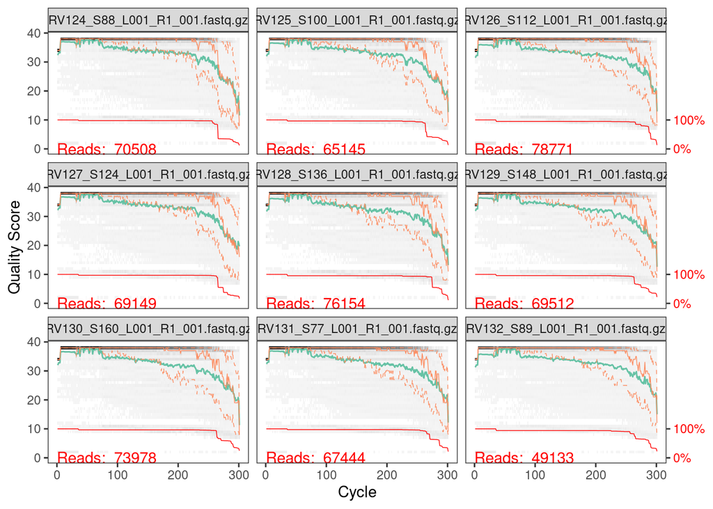

```r
plotQualityProfile(fnFs[c(1:9)])
```

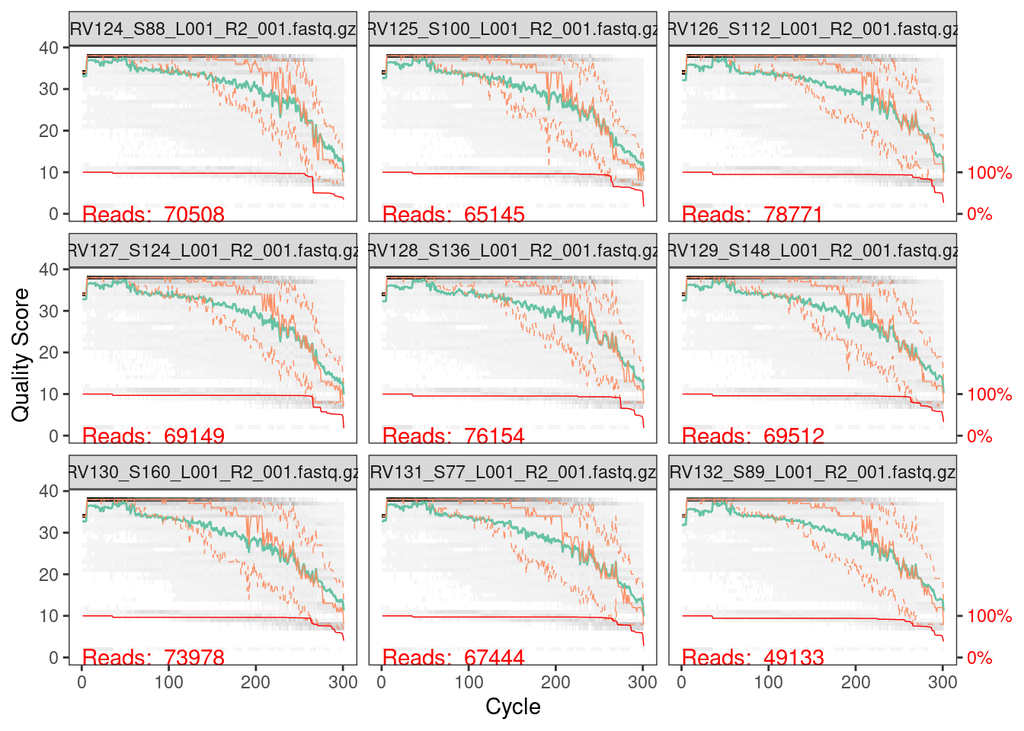

```r
plotQualityProfile(fnRs[c(1:9)])
```

Creating subdirectory and directing the filtered and trimmed sequences to the specified directory. We then applied the saved sample.names to the filtered sequences.

```r
filt_path <- file.path(path, "trimmed")
if(!file_test("-d", filt_path)) dir.create(filt_path)
filtFs <- file.path(path, "Filtered", paste0(sample.names, "_F_filt.fastq.gz"))
filtRs <- file.path(path, "Filtered", paste0(sample.names, "_R_filt.fastq.gz"))
names(filtFs) <- sample.names
names(filtRs) <- sample.names
```

Checking for presence of primer sequence in order to account for it in filtering.

```r
primerF<-grep("CTTGGTCATTTAGAGGAAGTAA", "RV238_S210_L001_R1_001.fastq.gz") #ITS1F forward primer
primerF
```

```
## integer(0)
```

```r
#integer(0) - primer was not found, has already been filtered! Also confirmed in the SCC terminal with grep function
primerR<-grep("GCTGCGTTCTTCATCGATGC", "RV238_S210_L001_R2_001.fastq.gz") #ITS4 reverse primer
primerR
```

```
## integer(0)
```

```r
#integer(0) - primer was not found, has already been filtered! Also confirmed in the SCC terminal with grep function
```

Filtering forward and reverse reads with predetermined quality cutoffs. TruncLen was set to 250 for forward reads and 200 for reverse reads based on the dropoff of quality below a quality score of 25, seen in the Quality Profile Plot. Every other parameter was set to the default argument.

```r
out <- filterAndTrim(fnFs, filtFs, fnRs, filtRs, truncLen= c(250,200),
                     maxN=0,
                     maxEE= c(2,2),
                     truncQ=2,
                     rm.phix=TRUE,
                     compress=TRUE, multithread=FALSE)
#Must filter reads together to prevent mis-match sorting that can affect merging of forward and reverse reads downstream

#Checking reads.in versus reads.out = Number of reads remaining after filtering with quality scores
head(out)
```

```
##                                 reads.in reads.out
## RV124_S88_L001_R1_001.fastq.gz     70508     49828
## RV125_S100_L001_R1_001.fastq.gz    65145     41239
## RV126_S112_L001_R1_001.fastq.gz    78771     51287
## RV127_S124_L001_R1_001.fastq.gz    69149     47341
## RV128_S136_L001_R1_001.fastq.gz    76154     48993
## RV129_S148_L001_R1_001.fastq.gz    69512     44871
```

```r
tail(out)
```

```
##                               reads.in reads.out
## RV58_S16_L001_R1_001.fastq.gz     3607      1466
## RV59_S27_L001_R1_001.fastq.gz     3820      1209
## RV60_S36_L001_R1_001.fastq.gz     2307       888
## RV61_S45_L001_R1_001.fastq.gz     5954      2640
## RV62_S54_L001_R1_001.fastq.gz     4106      1359
## RV63_S63_L001_R1_001.fastq.gz     2586       914
```

## Learning Error Rates

```r
setDadaOpt(MAX_CONSIST=30)
errF <- learnErrors(filtFs, multithread=TRUE)
```

```
## 101188750 total bases in 404755 reads from 9 samples will be used for learning the error rates.
```

```r
errR <- learnErrors(filtRs, multithread=TRUE)
```

```
## 105691000 total bases in 528455 reads from 12 samples will be used for learning the error rates.
```

Sanity check: We want to visualize error rates and make sure they are following a negative correlation with quality scores

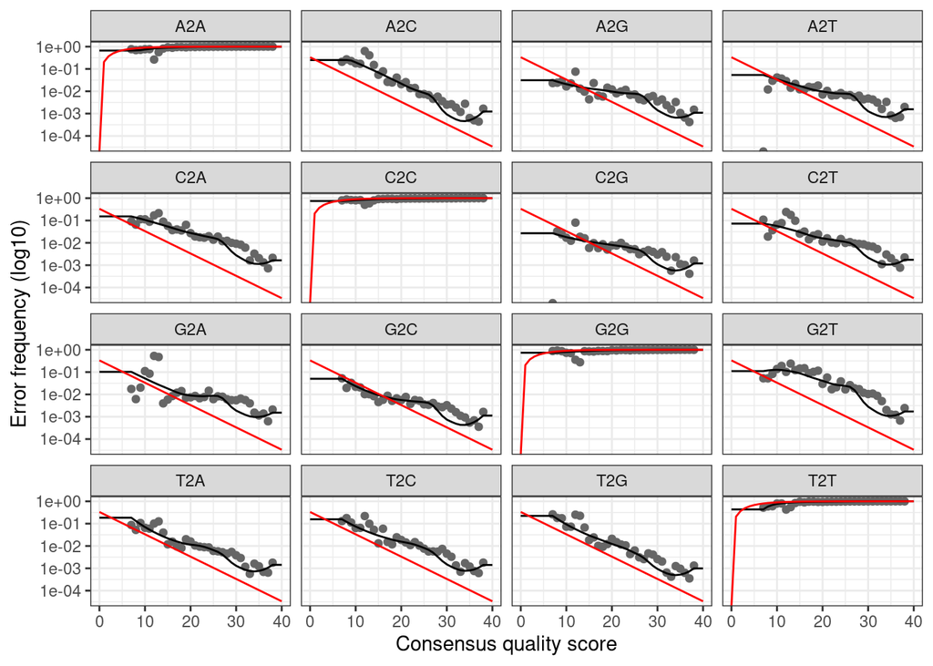

```r
plotErrors(errF, nominalQ=TRUE)
```

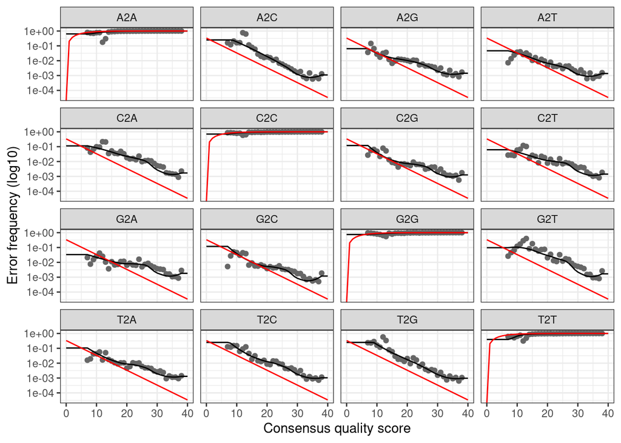

```r
plotErrors(errR, nominalQ=TRUE)
```

Our error rates look relatively okay, not strictly linear but definitely a negative correlation

## Dereplicating Reads

Reads were dereplicated into unique sequences and deseq objects were assigned to sample names

```r
derepFs <- derepFastq(filtFs, verbose=FALSE)
derepRs <- derepFastq(filtRs, verbose=FALSE)
names(derepFs) <-sample.names
names(derepRs) <-sample.names
```

## Inferring Sequence Variants

Applying the joint sample inference algorithm (infers sample sequences exactly and resolves differences of as little as 1 nucleotide) to get a the real variants as a dada class object. We set the band size to 32 as is recommended for ITS2 data.

```r
setDadaOpt(BAND_SIZE=32)
dadaFs <- dada(derepFs, err=errF, multithread=TRUE)
dadaRs <- dada(derepRs, err=errR, multithread=TRUE)

#Observing the dada class object by sample to identify number of sequence variants
dadaFs[[1]]
dadaFs[[29]]
```

Denoised forward reads were aligned with reverse-compliment corresponding denoised reverse reads to obtain full sequences

```r
mergers <- mergePairs(dadaFs, filtFs, dadaRs, filtRs, verbose=FALSE)
```

Constructing a sequence table (higher resolution otu table) The sequence table is a matrix with rows corresponding to (and named by) the samples, and columns corresponding to (and named by) the sequence variants

```r
seqtab <- makeSequenceTable(mergers)
dim(seqtab)
```

```
## [1]   29 1871
```

## Removing Chimeras

Dada accounts for substitution and indel errors but does not remove chimeras.

```r
seqtab.nochim <- removeBimeraDenovo(seqtab, method="consensus", multithread=TRUE, verbose=TRUE)
```

```
## Identified 16 bimeras out of 1871 input sequences.
```

```r
#Identified 16 bimeras out of 1871 input sequences
dim(seqtab.nochim)
```

```
## [1]   29 1855
```

```r
table(nchar(getSequences(seqtab.nochim))) #distribution of sequence lengths
```

```
##
## 250 251 252 253 254 255 256 257 258 259 260 261 262 263 264 265 266 267 268 269
##  25  13   6  11  12  15  26   7  12  17  12   8   7  20  12  18   7  15  12  18
## 270 271 272 273 274 275 276 277 278 279 280 281 282 283 284 285 286 287 288 289
##  14  20  10  14  13  15  20  22  16  20  26  17  15  21  14  19  23  27  17  24
## 290 291 292 293 294 295 296 297 298 299 300 301 302 303 304 305 306 307 308 309
##  40  47  34  17  41  16  18  16  18  18  20  16  19  12  25  18  18  10  11  23
## 310 311 312 313 314 315 316 317 318 319 320 321 322 323 324 325 326 327 328 329
##  14  17  21  23  14  12   8  21  19  15  11  10   5  15  11   8  14  10  12   7
## 330 331 332 333 334 335 336 337 338 339 340 341 342 343 344 345 346 347 348 349
##   4   7  11   6   6   4   3   7   6   3   9  10   8  10   9   8   7   3   9   7
## 350 351 352 353 354 355 356 357 358 359 360 361 362 363 364 365 366 367 368 369
##   5   3   6   7   5  10   6   7   8   6   2   7   4   5   3   6   7   4   4   6
## 370 371 372 373 374 375 376 377 378 379 381 382 383 384 385 386 387 389 390 391
##   2   7   7   3   2  13   8   1   5   3   4   3   2   7   4   4   3   7   5   4
## 392 393 394 395 396 397 398 399 400 401 402 403 404 405 406 407 408 409 410 411
##   1   6   6   4   3   6   7   8   8   6   2   3   3   4   3   6   4   4   4   5
## 412 413 414 415 416 418 419 420 421 422 423 424 425 426 427 428 429 430 431 432
##   8   3   4   2   3   3   8   4   4   1   1   1   1   5   4   3   1   2   2   1
## 433 434 436 437 438
##   3   2   3   5   2
```

```r
sum(seqtab.nochim)/sum(seqtab)
```

```
## [1] 0.9993371
```

Chimeras account for less than 1% of merged sequence variants

Writing the output of the original sequence table and the sequence table with chimeras removed

```r
write.csv(seqtab,file="pineinvasion_seqtab.csv")
write.csv(seqtab.nochim,file="pineinvasion_nochim.csv")
```

## Tracking Read Statistics

Producing a csv table output that allows us to track the read statistics throughout the pipeline. It displays the raw reads, how many reads were filtered, denoised, etc. The final number of reads is located under the nonchim column.

```r
getN <- function(x) sum(getUniques(x))
track <- cbind(out, sapply(dadaFs, getN), sapply(dadaFs, getN), rowSums(seqtab), rowSums(seqtab.nochim))
colnames(track) <- c("input", "filtered", "denoised", "merged", "tabled", "nonchim")
rownames(track) <- sample.names
head(track)
```

```
##       input filtered denoised merged tabled nonchim
## RV124 70508    49828    49588  49588  48588   48498
## RV125 65145    41239    41012  41012  39748   39713
## RV126 78771    51287    51103  51103  50206   50201
## RV127 69149    47341    47096  47096  46827   46822
## RV128 76154    48993    48854  48854  48255   48180
## RV129 69512    44871    44485  44485  43473   43314
```

Writing the track reads csv

```r
write.csv(track,file="ReadFilterStats_AllData_final.csv",row.names=TRUE,quote=FALSE)
```

## Assigning Taxonomy

```r
taxa <- assignTaxonomy(seqtab.nochim, "/project/bi594/Pine_invasion/sh_general_release_dynamic_s_04.02.2020.fasta", multithread=TRUE)
```

```
## UNITE fungal taxonomic reference detected.
```

```r
taxa.print <- taxa
rownames(taxa.print) <- NULL #this gets rid of the sequence column
```

Writing the taxa csv file and save reads for the downstream heatmap

```r
unname(head(taxa, 30))
unname(taxa)
taxa<- sub('...', '', taxa)
```

```r
write.csv(taxa, file="taxa.csv",row.name=TRUE,quote=FALSE)
saveRDS(seqtab.nochim, file="final_seqtab_nochim.rds")
saveRDS(taxa, file="final_taxa_blastCorrected.rds")
```

# Phyloseq

Loading in the previously saved data files and the variable table for phyloseq

```r
setwd("/project/bi594/Pine_invasion")
seqtab.nochim <- readRDS("final_seqtab_nochim.rds")
taxa <- readRDS("final_taxa_blastCorrected.rds")
samdf<-read.csv("variabletable_pi.csv", header = TRUE, sep = ',')
rownames(samdf) <- samdf$SAMPLE #making rownames the same as sample names in seq.nochim to merge in phyloseq
```

Constructing the phyloseq object

```r
ps <- phyloseq(otu_table(seqtab.nochim, taxa_are_rows=FALSE),
               sample_names(samdf),
               tax_table(taxa))
ps
```

```
## phyloseq-class experiment-level object
## otu_table()   OTU Table:         [ 1855 taxa and 29 samples ]
## tax_table()   Taxonomy Table:    [ 1855 taxa by 7 taxonomic ranks ]
```

## Generating Abundance Bar plot

Selecting the Top 90 most abundant taxa

```r
top90 <- names(sort(taxa_sums(ps), decreasing=TRUE))[1:90]
ps.top90 <- transform_sample_counts(ps, function(OTU) OTU/sum(OTU))
ps.top90 <- prune_taxa(top90, ps.top90)
```

Write a csv for the phyloseq data to hold the taxa abundances per sample. This will be useful for contructing the downstream heatmap.

```r
psz <- psmelt(ps)
psz90 <- psmelt(ps.top90)
```

```r
write.csv(psz, file="psz.csv")
write.csv(psz90, file="top90.csv")
```

Appending the meta-data to the phyloseq data

```r
colnames(psz)[2] <- "SampleID" #rename the sample ID column so we can merge the two dataframes by this column
fulldf <- merge(psz, samdf, by="SampleID")
#do the same for the top 90 taxa
colnames(psz90)[2] <- "SampleID" #rename the sample ID column so we can merge the two dataframes by this column
fulldf90 <- merge(psz90, samdf, by="SampleID")
```

Generating the barplot of fungal abundance by forest type separated by Class

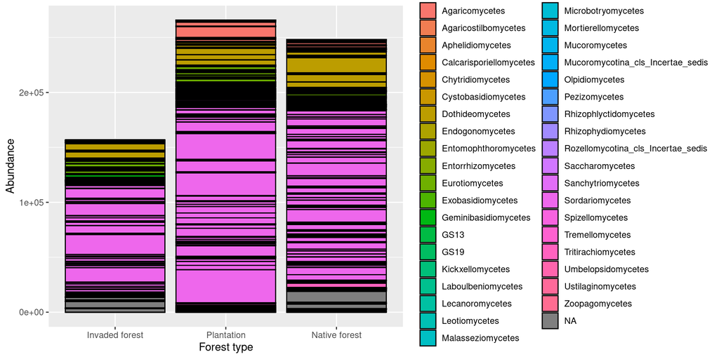

```r
p <- ggplot(fulldf, aes(x = site_code, y=Abundance, fill=Class))+
  labs(x="Forest type", fill = "Class")
p + geom_bar(stat="identity", colour="black") +
  scale_x_discrete(labels=c('Invaded forest', 'Plantation', "Native forest"))
```

**Figure 1. Barplot of taxa abundance by forest type.** The x-axis displays the categorical variables of forest type. The y-axis is total abundance of taxonomic class. From this figure we can conclude in the pine invaded forests there is an overall trend towards both a lower total abundance of taxa and a lower diversity of taxa relative to the other two forest types.

```r
ggsave("Abundance_Class.png", path = "/project/bi594/Pine_invasion/Figures/", width=10, height=6, dpi=300)
```

## Assigning Functional Groups

Assigning functional groups from the Funguild database (https://github.com/brendanf/FUNGuildR)

```r
funguild_input<- data.frame(taxa)
funguild_input$OTU <- row.names(funguild_input)
funguild_input$Taxonomy <- paste(funguild_input$Kingdom, funguild_input$Phylum, funguild_input$Class, funguild_input$Order, funguild_input$Family, funguild_input$Genus, funguild_input$Species, sep =';')
funguild_input<- subset(funguild_input, select=-c(Kingdom, Phylum, Class, Order, Family, Genus, Species))

guilds<- funguild_assign(funguild_input)
```

Then we add guild annotations onto the abundance data and generate another barplot of abundance by trophic mode

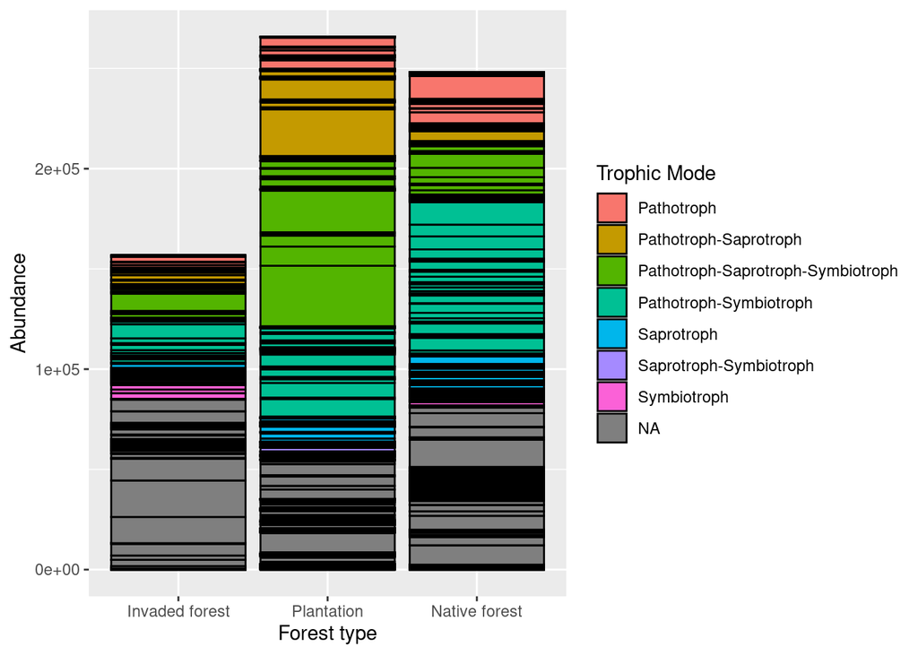

```r
fullguild<- merge(fulldf, guilds, by="OTU")

p2 <- ggplot(fullguild, aes(x = site_code, y=Abundance, fill=trophicMode))+
  labs(x="Forest type", fill = "Trophic Mode")
p2 + geom_bar(stat="identity", colour="black") +
  scale_x_discrete(labels=c('Invaded forest', 'Plantation', "Native forest"))
```

**Figure 2. Barplot of guild abundance by forest type.** The x-axis displays the categorical variables of forest type. The y-axis is total abundance of taxonomic class. Functional groups seem to differ across forest types which can impact soil nutrients across forest types.

It is important that abundances of functional groups differ across forest types because a taxa’s functional group can indicate its role in soil C and nutrient cycling. For example, saprotrophs are usually implicated in C cycling, while mycorrhizal fungi (“symbiotrophs”) are usually implicated in N and P cycling.

```r
ggsave("Abundance_Trophic.png", plot=p2, path = "/project/bi594/Pine_invasion/Figures/", width=10, height=6, dpi=300)
```

Collapsing taxonomy in OTU table for WGCNA input

```r
#Collapse the data in the phyloseq object to genus-level IDs
glom <- tax_glom(ps, taxrank = 'Genus')
#Create a dataframe of the OTUs and taxonomic assignments at the genus level
otu<- data.frame(otu_table(glom))
tax_table <- data.frame(tax_table(glom))
#Replace the sequences in the OTU table with corresponding Genus-level IDs
Genus<- tax_table$Genus
colnames(otu) <- Genus
```

Write the OTU that will be used as the input for WGCNA

```r
write.csv(otu,file="otu.csv")
```

# Weighted Gene Correlation Network Analysis

Now that we’ve taken a look at our fungal community data, we’d like to know how the fungal communities relate to soil carbon (C), nitrogen (N), and phosphorus (P). To do this, we use a Weighted Gene Correlation Network Analysis (WGCNA) that will relate the abundance of the genera present in each sample to the C, N, and P of that sample. This analysis will indicate if certain genera are associated with certain soil C, N, and P conditions.

Merging count data with Genus IDs and removing outlier samples. OTU cutoff was set really low so that most of the OTUs weren’t purged.

```r
setwd("/project/bi594/Pine_invasion")
countData<-read.csv("otu.csv", stringsAsFactors = FALSE)
colnames(countData)[1] = "Sample_ID"

count.trim <- purgeOutliers(countData,count.columns=2:282, otu.cut= .000000000001)
```

```
## [1] "samples with counts below z-score -2.5 :"
## [1] "RV55"
## [1] "zscores:"
## [1] -3.244466
## [1] "OTUs passing frequency cutoff  1e-12 : 281"
```

```r
rownames(count.trim)=count.trim$cdat
count.trim$cdat <- NULL
class(count.trim)
```

```
## [1] "data.frame"
```

Transposing data.frame into a matrix and changing column names to indicate the three forest types: Plantation, Invaded forest, and Native forest.

```r
t<- t(as.data.frame(lapply(count.trim,as.numeric)))
colnames(t) <- rownames(count.trim)
class(t)

sapply(t, is.numeric)
ncol(t)
nrow(t)
colnames(t) = c("PL1.1", "PL1.2", "PL1.3", "PL1.4", "PL1.5", "UN1.1", "UN1.2", "UN1.3","UN1.4","UN1.5", "INV1.1", "INV1.2", "INV1.3", "INV1.4", "PL2.1", "PL2.2", "PL2.3", "PL2.4", "PL2.5", "UN2.1", "UN2.3", "UN2.4", "UN2.5", "INV2.1", "INV2.2", "INV2.3", "INV2.4", "INV2.5")
```

Reading in treatment data and inserting samples from purge outliers.

```r
setwd("/project/bi594/Pine_invasion")
samdf<- read.csv("variabletable_pi.csv")
rownames(samdf)[samdf$SampleID=='RV55']
```

```
## [1] "21"
```

```r
samdf.trim <- samdf[-c(21),]
treat=samdf.trim$site_code
g=data.frame(treat)
```

Creating colData for DESeq.

```r
colData<- g
class(colData)
```

```
## [1] "data.frame"
```

```r
str(colData)
```

```
## 'data.frame':    28 obs. of  1 variable:
##  $ treat: chr  "PL" "PL" "PL" "PL" ...
```

```r
nrow(colData)
```

```
## [1] 28
```

Running DeSeq to filter out very low counts

Constructing DESeqDataSet Object.

```r
dds<-DESeqDataSetFromMatrix(countData=t, colData=colData, design=~ treat)
```

Calculating geometric means of the counts. Estimating size factors to get the relative library depth of the samples and running DESeq function.

```r
gm_mean = function(x, na.rm=TRUE){
  exp(sum(log(x[x > 0]), na.rm=na.rm) / length(x))
}
geoMeans = apply(counts(dds), 1, gm_mean)
dds = estimateSizeFactors(dds, geoMeans = geoMeans)
dds = DESeq(dds, fitType="local")
```

Transform the count data to the log2 scale in a way which minimizes differences between samples for rows with small counts. This normalizes with respect to library size. Also making a matrix of our rlog data.

```r
rld <- rlogTransformation(dds, blind=TRUE, fitType="local")
rld_wg=(assay(rld))
nrow(rld_wg)
```

```
## [1] 281
```

Writing csv for transformed data to take into WGCNA.

```r
write.csv(rld_wg,file="Invasion_wgcna_allgenes2.csv",quote=F,row.names=T)
```

Data input and cleaning. Transposing the expression data for further analysis.

```r
options(stringsAsFactors=FALSE)
allowWGCNAThreads()
```

```
## Allowing multi-threading with up to 28 threads.
```

```r
setwd("/project/bi594/Pine_invasion")
dat=read.csv("Invasion_wgcna_allgenes2.csv")
rownames(dat)<-dat$X
dat$X=NULL
names(dat)
```

```
##  [1] "PL1.1"  "PL1.2"  "PL1.3"  "PL1.4"  "PL1.5"  "UN1.1"  "UN1.2"  "UN1.3"
##  [9] "UN1.4"  "UN1.5"  "INV1.1" "INV1.2" "INV1.3" "INV1.4" "PL2.1"  "PL2.2"
## [17] "PL2.3"  "PL2.4"  "PL2.5"  "UN2.1"  "UN2.3"  "UN2.4"  "UN2.5"  "INV2.1"
## [25] "INV2.2" "INV2.3" "INV2.4" "INV2.5"
```

```r
nrow(dat)
```

```
## [1] 281
```

```r
datExpr0 = as.data.frame(t(dat))
```

Reading in trait data and matching the samples to the expression samples for which they were measured (linking things correctly). Also, inserting samples removed from purgeoutliers

```r
setwd("/project/bi594/Pine_invasion")
traitData= read.csv("Invasion_traits_WGCNA.csv")
rownames(traitData)[traitData$Sample_ID=='RV55']
```

```
## [1] "21"
```

```r
trait.trim <- traitData[-c(21),]
rownames(trait.trim) <- trait.trim$Sample_ID
trait.trim$Sample_ID <- NULL
dim(trait.trim)
```

```
## [1] 28  3
```

```r
names(trait.trim)
```

```
## [1] "percN" "percC" "P"
```

Creating a data frame analogous to expression data that will hold the clinical traits.

```r
dim(datExpr0)
```

```
## [1]  28 281
```

```r
rownames(datExpr0)
```

```
##  [1] "PL1.1"  "PL1.2"  "PL1.3"  "PL1.4"  "PL1.5"  "UN1.1"  "UN1.2"  "UN1.3"
##  [9] "UN1.4"  "UN1.5"  "INV1.1" "INV1.2" "INV1.3" "INV1.4" "PL2.1"  "PL2.2"
## [17] "PL2.3"  "PL2.4"  "PL2.5"  "UN2.1"  "UN2.3"  "UN2.4"  "UN2.5"  "INV2.1"
## [25] "INV2.2" "INV2.3" "INV2.4" "INV2.5"
```

```r
datTraits=trait.trim
row.names(datTraits)= c("PL1.1", "PL1.2", "PL1.3", "PL1.4", "PL1.5", "UN1.1", "UN1.2", "UN1.3","UN1.4","UN1.5", "INV1.1", "INV1.2", "INV1.3", "INV1.4", "PL2.1", "PL2.2", "PL2.3", "PL2.4", "PL2.5", "UN2.1", "UN2.3", "UN2.4", "UN2.5", "INV2.1", "INV2.2", "INV2.3", "INV2.4", "INV2.5")
```

Returns true indicating dataset is aligned correctly.

```r
table(rownames(datTraits)==rownames(datExpr0))
```

```
##
## TRUE
##   28
```

Clustering the samples by expression to create a sample dendogram and trait heatmap. First whole network connectivity was calculated and standardized. Trait colors converted such that red illustrates high values.

```r
A=adjacency(t(datExpr0))

k=as.numeric(apply(A,2,sum))-1
Z.k=scale(k)
thresholdZ.k=-2.5
outlierColor=ifelse(Z.k<thresholdZ.k,"red","black")

sampleTree = flashClust(as.dist(1-A), method = "average")

traitColors=data.frame(numbers2colors(datTraits,signed=FALSE))
dimnames(traitColors)[[2]]=paste(names(datTraits))
datColors=data.frame(outlierC=outlierColor,traitColors)
```

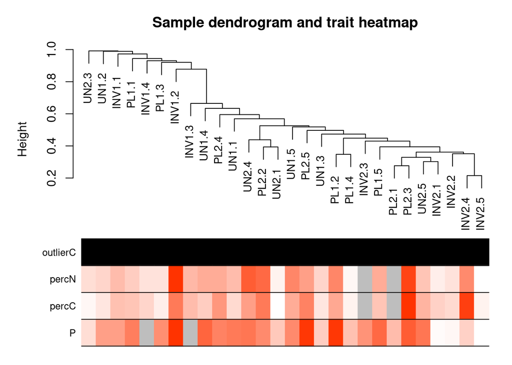

**Figure 3. Sample dendogram and trait heat map.** Red indicates high values. The first band indicates that there were no outliers. The following three bands depict soil percent nitrogen, percent carbon, and bulk phosphorus respectively.

```r
plotDendroAndColors(sampleTree,groupLabels=names(datColors), colors=datColors,main="Sample dendrogram and trait heatmap")
```

## Network Construction and Module Detection

Setting our working environment and loading in previously saved expression and trait data.

```r
options(stringsAsFactors = FALSE)
setwd("/project/bi594/Pine_invasion")
lnames = load(file="Invasion_Samples_Traits_ALL2.RData")
```

## Determining the soft power threshold

The Soft power threshold is the power to which co-expression similarity is raised in order to calculate adjacency. It is standard (according to approximate scale-free topology criterion) to select a soft power threshold that corresponds to a scale free topology model fit (R^2) greater than 0.8. If the value of SFT.R.sq does not reach this threshold within a reasonable power (less than 15 for signed data) then the soft power threshold can be decided based on sample size.

https://horvath.genetics.ucla.edu/html/CoexpressionNetwork/Rpackages/WGCNA/faq.html

First we must set parameters for a set of cadidate soft-threshold powers to plot and visualize scale independence and mean connectivity.

```r
#Standard setting
powers = c(seq(1, 10, by = 1), seq(12, 20, by = 2))
#Producing SFT.R.sq way too small
```

```r
#adjusting power values just to see if .8 threshold could be reached (it cannot)
#powers = c(seq(100, 190,by=10), seq(200,250, by=5))
```

Plotting Scale Independence and Mean Connectivity to determine soft-power threshold based on the sclae free topology index and mean connectivity as functions of the soft power threshold.

```r
# Call the network topology analysis function
sft = pickSoftThreshold(datExpr0, powerVector = powers, networkType="signed", verbose = 2)
```

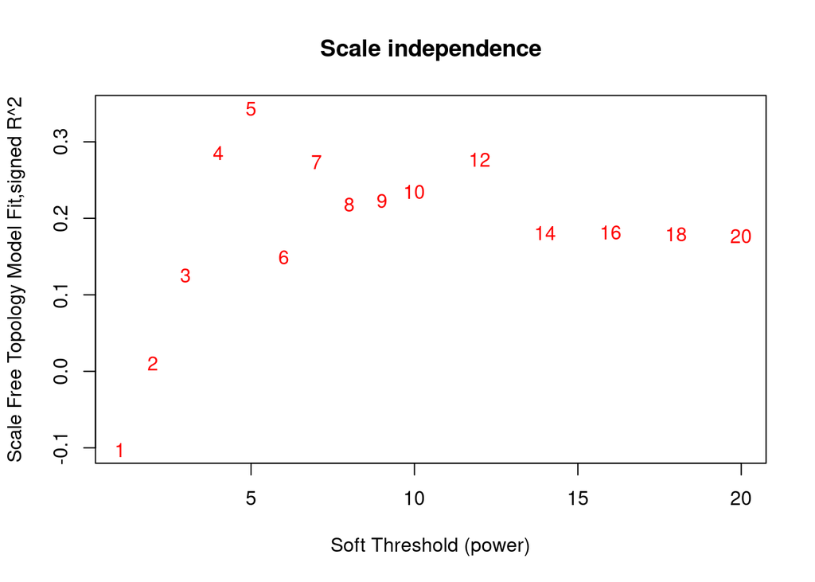

```r
plot(sft$fitIndices[,1], -sign(sft$fitIndices[,3])*sft$fitIndices[,2],
     xlab="Soft Threshold (power)",ylab="Scale Free Topology Model Fit,signed R^2",type="n",
     main = paste("Scale independence"));
text(sft$fitIndices[,1], -sign(sft$fitIndices[,3])*sft$fitIndices[,2],
     labels=powers, col="red");
# this line corresponds to using an R^2 cut-off (want it to be between .8 and .9 when selecting sft)
abline(h=0.90,col="red")
```

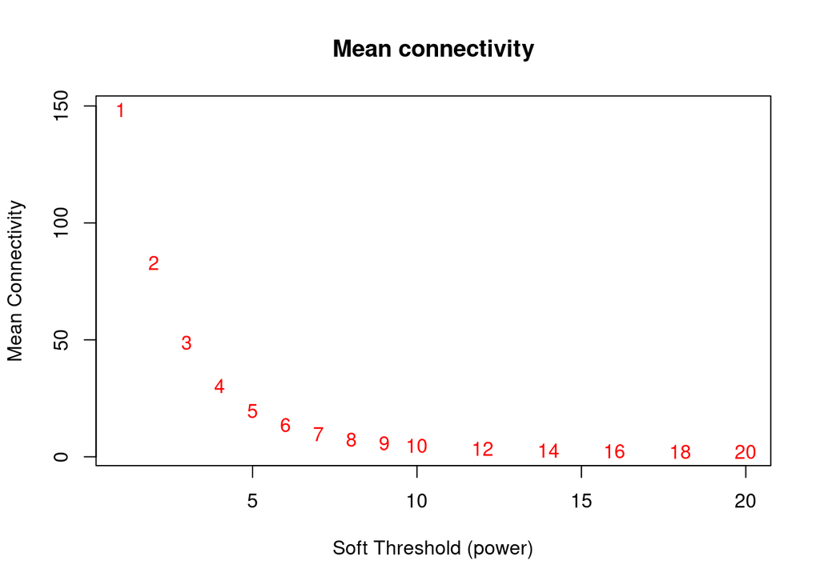

```r
plot(sft$fitIndices[,1], sft$fitIndices[,5],
     xlab="Soft Threshold (power)",ylab="Mean Connectivity", type="n",
     main = paste("Mean connectivity"))
text(sft$fitIndices[,1], sft$fitIndices[,5], labels=powers, col="red")
```

```r
softPower=16
```

Then we will construct the adjacency matrix that will be utilized to create our initial dendrogram. The adjacency function calculates (correlation or distance) network adjacency from given expression data or from similarity. We want to use signed correlation (this is the default) because we want to create modules with similar abundance patterns for easier biological interpretation of the final output.

```r
adjacency=adjacency(datExpr0, power=softPower,type="signed")
```

## Create dendrogram

Now, we want to visualize how the genera group together based on their abundances across samples. For example, genera that regularly appear together in the same samples will cluster together.

We translate the adjacency into a topological overlap matrix and calculate the corresponding dissimilarity:

```r
TOM= TOMsimilarity(adjacency,TOMType = "signed")
```

```
## ..connectivity..
## ..matrix multiplication (system BLAS)..
## ..normalization..
## ..done.
```

```r
dissTOM= 1-TOM
```

Then, we create the tree that clusters genera together based on similarity in abundances. Each leaf corresponds to a genus, and branches grouping together densely are genera that frequently occur together.

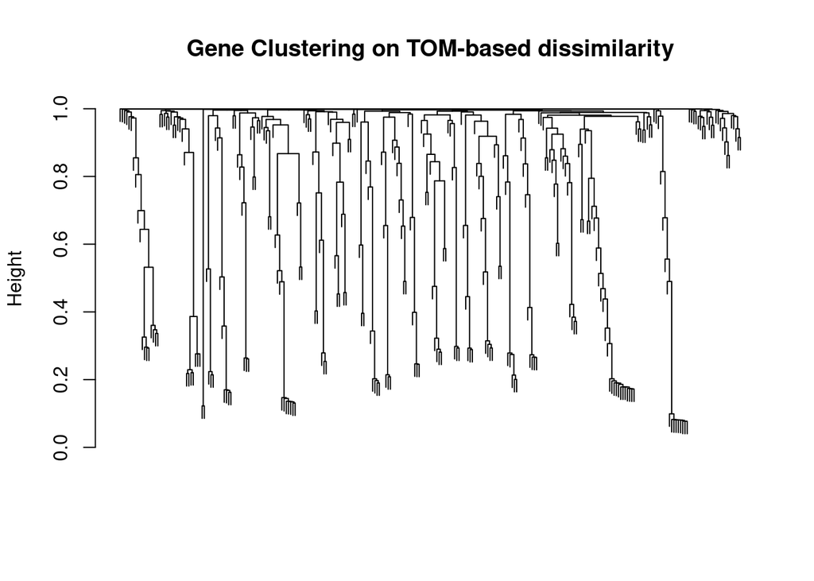

```r
library(flashClust)
geneTree= flashClust(as.dist(dissTOM), method="average") #do we want to change method back to default?
plot(geneTree, xlab="", sub="", main= "Gene Clustering on TOM-based dissimilarity", labels= FALSE,hang=0.04)
```

Next, we set the smallest number of genera that can be included in a module. We chose 5 because there are 281 genera, so higher than 5 would be a very high percentage of all genera. But, less than 5 would be too few genera to consider a cluster.

```r
minModuleSize=5
dynamicMods= cutreeDynamic(dendro= geneTree, distM= dissTOM, deepSplit=2, pamRespectsDendro= FALSE, minClusterSize= minModuleSize)
```

```
##  ..cutHeight not given, setting it to 0.991  ===>  99% of the (truncated) height range in dendro.
##  ..done.
```

```r
table(dynamicMods)
```

```
## dynamicMods
##  0  1  2  3  4  5  6  7  8  9 10 11 12 13 14 15 16 17 18 19 20 21
## 35 30 19 16 15 14 13 13 13 12 12 12 11 10  9  8  7  7  7  7  6  5
```

From this table, we can see that we have 21 modules. 35 taxa were unable to be placed into a module.

Next, we assign colors to each module and plot the colors below the dendrogram to show which branches belong to which module.

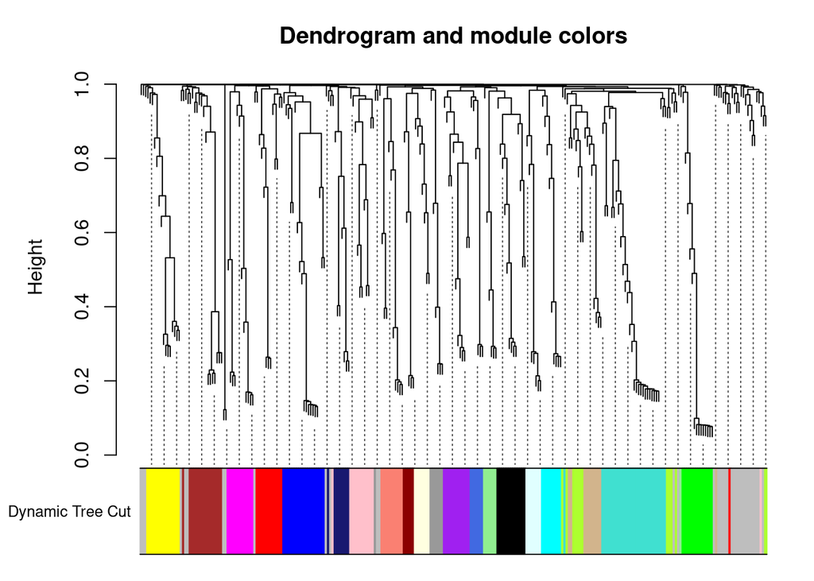

```r
dynamicColors= labels2colors(dynamicMods) #assigning colors to each module
plotDendroAndColors(geneTree, dynamicColors, "Dynamic Tree Cut", dendroLabels= FALSE, hang=0.03, addGuide= TRUE, guideHang= 0.05, main= "Dendrogram and module colors")
```

**Figure 4. Dendrogram and module colors.** Each leaf of the tree corresponds to a genus, and branches grouping together densely are genera that frequently occur together. The colors on the Dynamic Tree Cut band correspond to the module groupings of genera. No modules have been merged.

## Merge modules

Because some modules have similar genera abundance profiles, we want to merge those modules into one. With gene expression data, an eigengene is calculated for each module, which is a representative expression value for each module. We do the same here, except with abundances instead of gene expression values.

```r
#calculate eigengenes
MEList= moduleEigengenes(datExpr0, colors= dynamicColors,softPower = 16)
MEs= MEList$eigengenes
#Calculate dissimilarity of module eigenegenes
MEDiss= 1-cor(MEs)
#Cluster module eigengenes
METree= flashClust(as.dist(MEDiss), method= "average")
```

We reload the saved data:

```r
setwd("/project/bi594/Pine_invasion")
lnames <- load(file = "Network_invasion_0.7.RData")
```

Then, we plot a tree of the modules and add a line to show where we merge the modules. Any modules below the red line will be merged to the closest branch above the line. We chose 0.7 as the merging height because any value less than 0.7 resulted in many modules with similar abundance patterns.

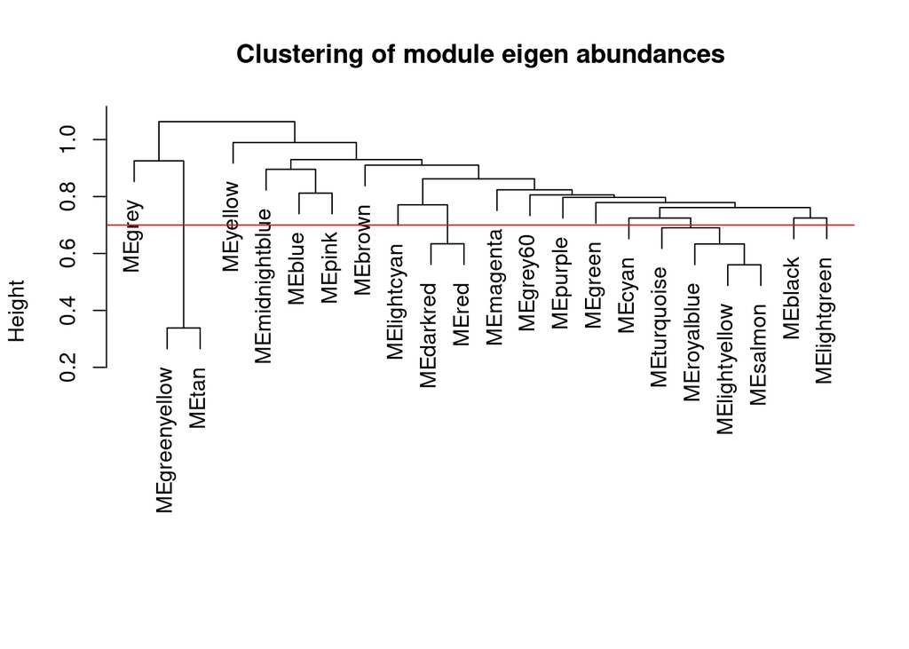

```r
plot(METree, main= "Clustering of module eigen abundances", xlab= "", sub= "")

MEDissThres= 0.7 #*we can change the threshold of our height, merges them different based on value, dont want to overmerge things that arent that similar
abline(h=MEDissThres, col="red")
```

**Figure 5. Tree clustering of module eigen abundances based on similarity.** Each branch of the tree represents a module. The red line shows the height at which we merged modules, which was 0.7.

The below code executes the actual merging of modules. We then plot the same dendrogram as previously, but with an added annotation below showing the new modules and colors after merging.

```r
merge= mergeCloseModules(datExpr0, dynamicColors, cutHeight= MEDissThres, verbose =1)
```

```
##  mergeCloseModules: Merging modules whose distance is less than 0.7
##    Calculating new MEs...
```

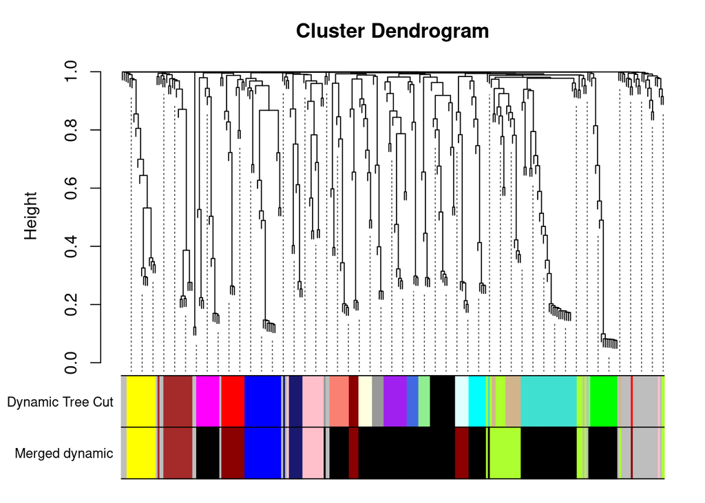

```r
mergedColors= merge$colors
mergedMEs= merge$newMEs

plotDendroAndColors(geneTree, cbind(dynamicColors, mergedColors), c("Dynamic Tree Cut", "Merged dynamic"), dendroLabels= FALSE, hang=0.03, addGuide= TRUE, guideHang=0.05)
```

**Figure 6. Dendrogram and module colors post-merging.** Each leaf of the tree corresponds to a genus, and branches grouping together densely are genera that frequently occur together. The colors on the Dynamic Tree Cut band correspond to the module groupings of genera without mergin. The colors on the Merged dynamic band correspond to the module groupings after merging at a height of 0.7.

```r
moduleColors= mergedColors
colorOrder= c("grey", standardColors(50)) #here we indicate that genera that cannot be assigned to a module are assigned the color grey
moduleLabels= match(moduleColors, colorOrder)-1
MEs=mergedMEs

#save module colors and labels for use in subsequent parts
save(MEs, moduleLabels, moduleColors, geneTree, file= "Network_signed_0.7.RData")
```

## Relating modules to traits and finding important genes

The following setting is important, do not omit:

```r
options(stringsAsFactors = FALSE);
```

This code creates variables for the number of genera and the number of samples. Then we view a table of the module colors which shows how many genera are in each module.

```r
nGenes = ncol(datExpr0)
nSamples = nrow(datExpr0)
table(moduleColors)
```

```
## moduleColors
##        black         blue        brown      darkred  greenyellow         grey
##          127           19           16           25           23           35
## midnightblue         pink       yellow
##            8           13           15
```

Next, we recalculate the module eigengenes with color labels.

```r
MEs0 = moduleEigengenes(datExpr0, moduleColors)$eigengenes
MEs = orderMEs(MEs0)
moduleTraitCor = cor(MEs, datTraits, use = "p");
moduleTraitPvalue = corPvalueStudent(moduleTraitCor, nSamples);
```

### Module heatmap

Now, we want to relate our modules to our traits, which are soil total C, N, and P. To do this, we represent module trait correlations as a heatmap, where each row represents a module and each column represents a trait. If a module is significant for a particular trait, it will show a low p-value (usually significance is considered p<0.05, but because of our low sample size, we will consider p<0.1 to be significant for this assignment). Significance indicates that the genera present in that module are frequently associated with either a high or low value of that trait.

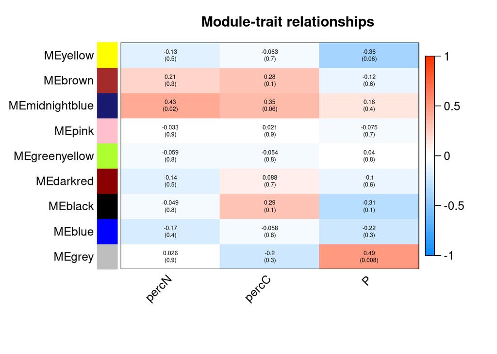

```r
# Will display correlations and their p-values
textMatrix = paste(signif(moduleTraitCor, 2), "\n(",
                   signif(moduleTraitPvalue, 1), ")", sep = "");
dim(textMatrix) = dim(moduleTraitCor)
par(mar = c(6, 8.5, 3, 3));
# Display the correlation values within a heatmap plot
labeledHeatmap(Matrix = moduleTraitCor,
               xLabels = names(datTraits),
               yLabels = names(MEs),
               ySymbols = names(MEs),
               colorLabels = FALSE,
               colors = blueWhiteRed(50),
               textMatrix = textMatrix,
               setStdMargins = FALSE,
               cex.text = 0.5,
               zlim = c(-1,1),
               main = paste("Module-trait relationships"))
```

**Figure 7. Heatmap of module-trait relationships.** Each row represents a module and each column represents a trait. Red cells indicate that the genera in that module are positively associated with the trait, and blue cells indicate that the genera in that module are negatively associated with the trait. The top number in each cell indicates the correlation between the module and the trait, and the number in parentheses below the correlation value is the p-value showing significance of the correlation. Significance indicates that the genera present in that module are frequently associated with either a high or low value of that trait.

This heatmap looks good, because we can tell that we did not under-merge our modules. If we had not merged our modules enough, you would see blocks of modules next to each other that have similar profiles (for example, large chunks of blue or red modules together).

Here, we can see that the yellow module is significant for P, but negatively associated with P. In other words, genera in this module are frequently associated with low P. The midnight blue module is significant for C and N, where the genera in this module are frequently associated with high C and N. Additionally, P is positively associated with genera that could not be assigned to a module (grey). However, because of the difficulty to interpret significance of unassigned genera, we will not consider the grey module in this analysis.

Next, we quantify associations of individual genera with our traits by defining (the absolute value of) the correlation between the genus and the trait. For each module, we also define module membership (MM), which is a measure of the correlation of the module eigengene and the genera abundance profile. The similarity of every genera to every module is quantified.

```r
weight = as.data.frame(datTraits$P); #Here, you can change to your trait of interest. We use soil P here.
names(weight) = "bulk P"
# names (colors) of the modules
modNames = substring(names(MEs), 3)
geneModuleMembership = as.data.frame(cor(datExpr0, MEs, use = "p"));
MMPvalue = as.data.frame(corPvalueStudent(as.matrix(geneModuleMembership), nSamples));
names(geneModuleMembership) = paste("MM", modNames, sep="");
names(MMPvalue) = paste("p.MM", modNames, sep="");
geneTraitSignificance = as.data.frame(cor(datExpr0, weight, use = "p"));
GSPvalue = as.data.frame(corPvalueStudent(as.matrix(geneTraitSignificance), nSamples));
names(geneTraitSignificance) = paste("GS.", names(weight), sep="");
names(GSPvalue) = paste("p.GS.", names(weight), sep="")
```

### Module correlation plot

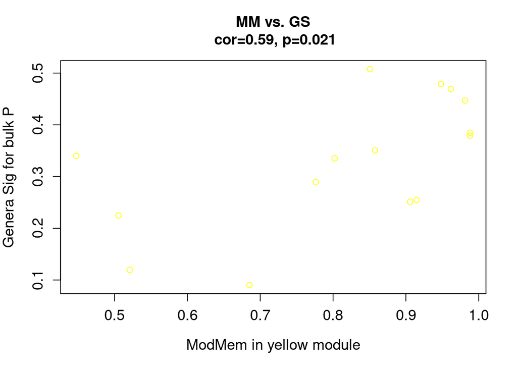

```r
module = "yellow" #*change this to the module we're going to look at
column = match(module, modNames);
moduleGenes = moduleColors==module;
par(mfrow = c(1,1));
verboseScatterplot(abs(geneModuleMembership[moduleGenes, column]),
                   abs(geneTraitSignificance[moduleGenes, 1]),
                   xlab = paste("ModMem in", module, "module"),
                   ylab = "Genera Sig for bulk P",
                   main = paste("MM vs. GS\n"),
                   cex.main = 1.2, cex.lab = 1.2, cex.axis = 1.2, col = module)
```

**Figure 8. Scatterplot of genera significance for bulk P vs. genera module membership in the yellow module.** Each point represents one genus in the module. Module membership in the yellow module for a given genus is a measure of the correlation of the module eigengene and the genus abundance profile. A tighter positive correlation between module membership and genera significance indicates higher significance of the module. “cor” is the correlation value, and “p” indicates the significance of the correlation.

### Identify genera in each module and their kMEs

We now want to know which genera fit best into our module out of all the genera in the module. To do this, we calculate a kME score for all genera, which indicates how well each genus fits into each module. A higher kME indicates a better fit in the module.

```r
setwd("/project/bi594/Pine_invasion/")
vsd <- read.csv("Invasion_wgcna_allgenes2.csv", row.names=1)
options(stringsAsFactors=FALSE)
data=t(vsd)
allkME =as.data.frame(signedKME(data, MEs))
```

Then, we have to subset the genera in our module of interest from all of the genera. To do this, we first create a data frame for our module that lists all the genera and scores them as either belonging in the module (“1”) or not belonging in the module (“0”).

```r
whichModule="yellow"

length(moduleColors)
```

```
## [1] 281
```

```r
inModule=data.frame("module"=rep(0,nrow(vsd)))
row.names(inModule)=row.names(vsd)
genes=row.names(vsd)[moduleColors == whichModule]
inModule[genes,1]=1
sum(inModule[,1]) #this should be the same number of genera that was in the module
```

```
## [1] 15
```

```r
write.csv(inModule,file=paste(whichModule,"_fisher.csv",sep=""),quote=F)
```

Now, we can extract a list of the genera in the module.

```r
yellow <- subset(inModule, module=="1")
yellow <- row.names(yellow)
yellow
```

```
##  [1] "Cylindrodendrum"     "Chaetomium"          "Xenasmatella"
##  [4] "Cystobasidium"       "Cladophialophora"    "Occultifur"
##  [7] "Leucosporidium"      "Meliniomyces"        "Densospora"
## [10] "Trechispora"         "Vishniacozyma"       "Filobasidium"
## [13] "Spencermartinsiella" "Zymoseptoria"        "Fistulinella"
```

We then create a dataframe of the kMEs of all the genera for just our module of interest:

```r
modColName=paste("kME",whichModule,sep="")
modkME=as.data.frame(allkME[,modColName])
row.names(modkME)=row.names(allkME)
names(modkME)=modColName
```

```r
write.csv(modkME,file=paste(whichModule,"_kME.csv",sep=""),quote=F)
```

From this dataframe, we then subset just the genera in our module of interest:

```r
ykmeinput<- paste(yellow, sep=",")
yellowkme<- subset(modkME, rownames(modkME) %in% ykmeinput)
Genus <- rownames(yellowkme)
rownames(yellowkme) <- NULL
yellowkme <- cbind(Genus,yellowkme)
```

And now, we can plot the kMEs of the genera in our module of interest to see which genera fit best into the module.

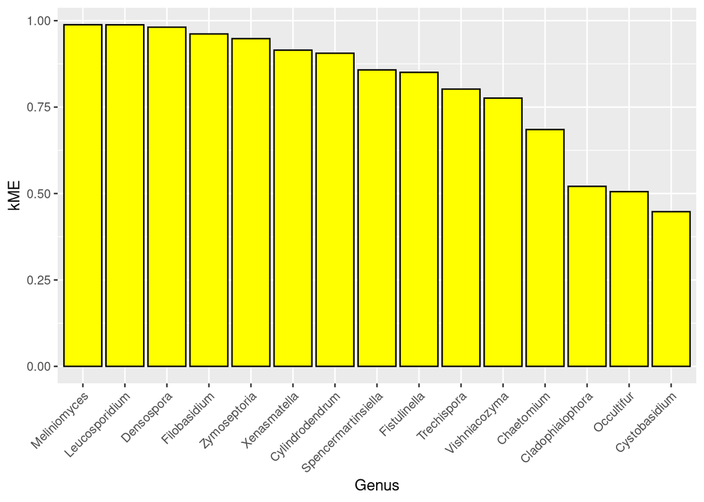

```r
ggplot(data= yellowkme, aes(x=reorder(Genus, -kMEyellow), y=kMEyellow)) +
  geom_bar(color= "black", fill="yellow", stat="identity") +
  theme(axis.text.x=element_text(angle=45,hjust=1,vjust=1)) +
  labs(x="Genus", y="kME")
```

**Figure 9. Barplot of genera in the yellow module vs. their kMEs for the module.** Increasing kME indicates that the genus fits better into the module.

We can conclude here that these genera are associated with low soil P, and may be drivers of low soil P. The genera with the highest kMEs may be key genera that are driving low soil P: *Meliniomyces*, *Leucosporidium*, and *Densospora*.

### Heatmaps of module genera abundances by sample

To see how module genera abundances change between samples, we can create a heatmap showing the abundance of each genus in each sample.

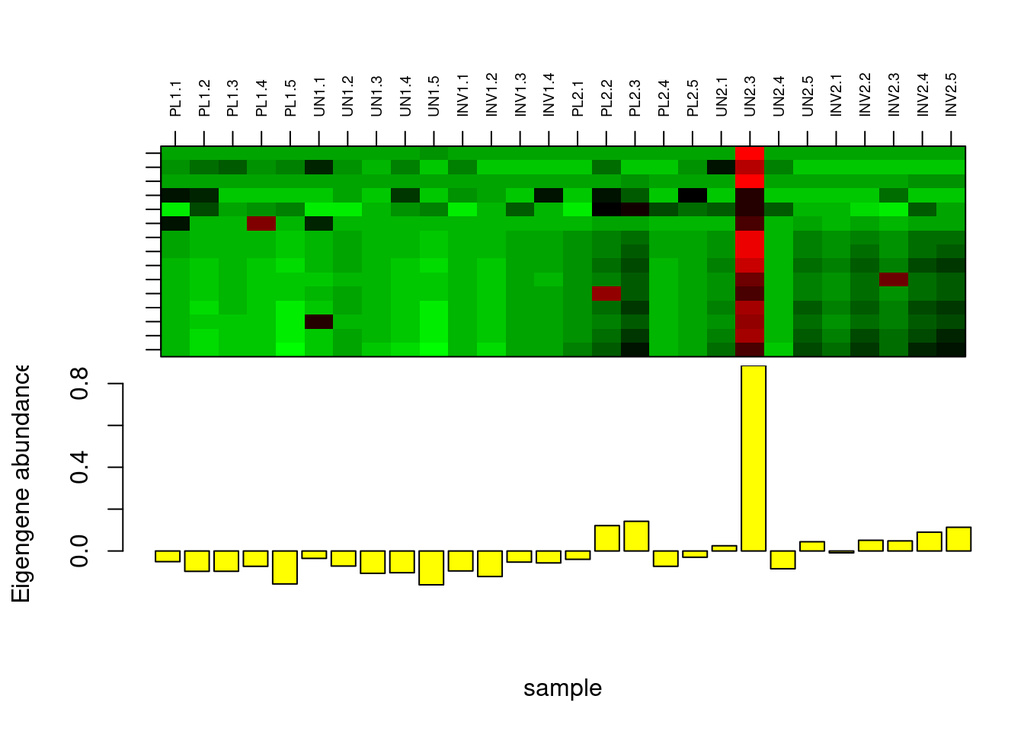

```r
which.module="yellow" #*change this also to the color of module we're looking at
#pick module of interest
ME=MEs[, paste("ME",which.module, sep="")]
genes=datExpr0[,moduleColors==which.module ] #replace where says subgene below to plot all rather than just subset

#quartz()
# par(mfrow=c(2,1), mar=c(0.3, 5.5, 3, 2))
par(mfrow=c(2,1), mar=c(0.3, 5.5, 5, 2))
plotMat(t(scale(genes) ),nrgcols=30,rlabels=F, clabels=rownames(genes), rcols=which.module)
par(mar=c(5, 4.2, 0, 0.7))
barplot(ME, col=which.module, main="", cex.main=2,
        ylab="Eigengene abundances",xlab="sample")
```

**Figure 10. Heatmap of genera abundances in each sample in the yellow module and eigengene abundance barplot.** Columns of the heatmap represent samples and rows represent each genus in the yellow module. Red indicates higher abundance of a genus and light green represents lower abundance. Higher bars in the barplot indicate higher abundances of genera in the yellow module in a given sample. ‘PL’ samples are from pine plantations, ‘UN’ samples are from uninvaded eucalypt forests adjacent to invaded forests, and ‘INV’ are from pine-invaded eucalypt forests.

To see how the abundance of module genera in each sample is associated with the soil P in each sample, we plot the same heatmap as before alongside a barplot of soil P in each sample.

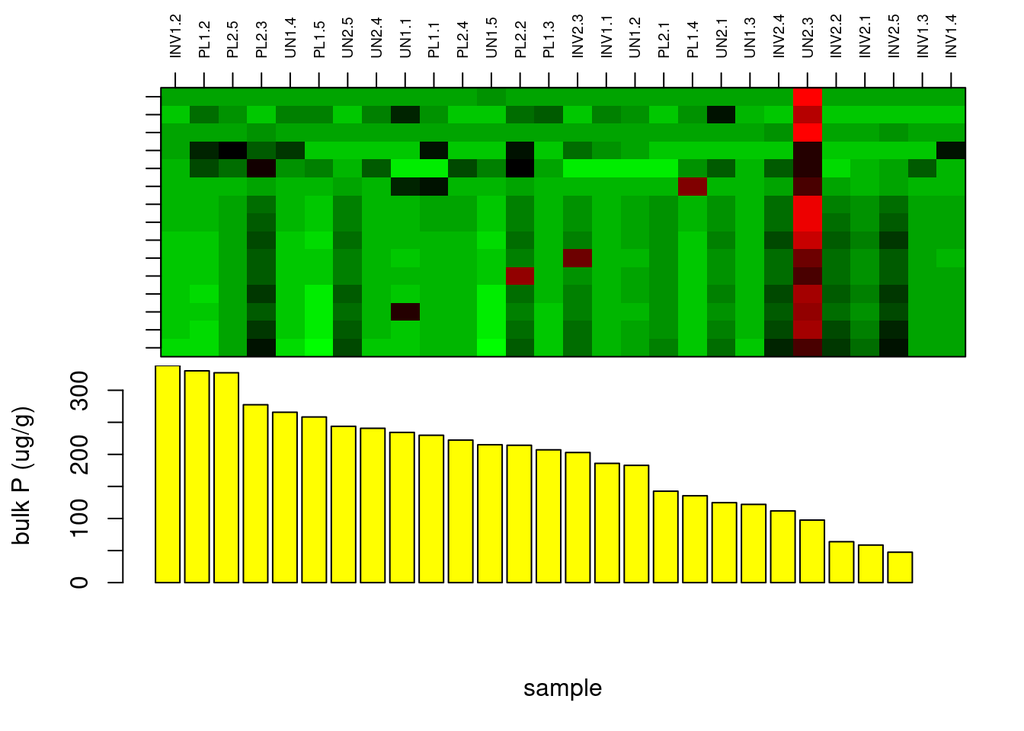

```r
which.module="yellow" #pick module of interest
which.trait="P" #change trait of interest here
datTraits=datTraits[order((datTraits$P),decreasing=T),]#change trait of interest here

trait=datTraits[, paste(which.trait)]
genes=datExpr0[,moduleColors==which.module ] #replace where says subgene below to plot all rather than just subset
genes=genes[rownames(datTraits),]

#quartz()
par(mfrow=c(2,1), mar=c(0.3, 5.5, 3, 2))
plotMat(t(scale(genes) ),nrgcols=30,rlabels=F, clabels=rownames(genes), rcols=which.module)
par(mar=c(5, 4.2, 0, 0.7))
barplot(trait, col=which.module, main="", cex.main=2,
        ylab="bulk P (ug/g)",xlab="sample")#change trait of interest here
```

**Figure 11. Heatmap of genera abundances in each sample in the yellow module and barplot of bulk soil P.** Columns of the heatmap represent samples and rows represent each genus in the yellow module. Red indicates higher abundance of a genus and light green represents lower abundance. Increasing values on the y-axis of the barplot indicate more bulk P in a soil sample. “PL” samples are from pine plantations, “UN” samples are from uninvaded eucalypt forests adjacent to invaded forests, and “INV” are from pine-invaded eucalypt forests.

In this figure, we can see that samples with lower bulk P also have higher abundances of genera in the yellow module, confirming the correlation between the yellow module and lower soil P.

### Exploring other significant modules

Now, to explore the other significant module, midnightblue, we do the same steps that we did with the yellow module but with %N as the trait of interest. We first created a scatter plot of genera significance for %N against the module membership in the midnightblue module. We can see in this plot that there is a positive correlation between the module and %N, so the module is indeed significant.

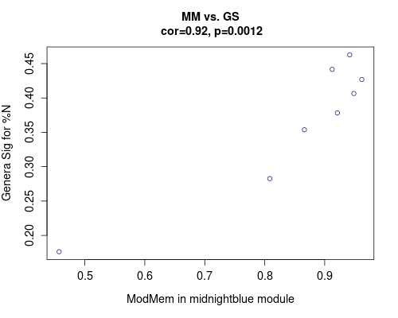

**Figure 12. Scatterplot of genera significance for %N vs. genera module membership in the midnightblue module.** Each point represents one genus in the module. Module membership in the midnightblue module for a given genus is a measure of the correlation of the module eigengene and the genus abundance profile. A tighter positive correlation between module membership and genera significance indicates higher significance of the module. cor is the correlation value, and p indicates the significance of the correlation.

The plot of kME by genera for the midnightblue module shows which genera are in the module and how well they belong.

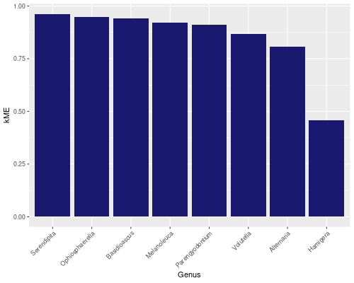

**Figure 13. Barplot of genera in the midnightblue module vs. their kMEs for the module.** Increasing kME indicates that the genus fits better into the module.

We made the same heatmaps as with the yellow module, plotting the genera abundances in each sample alongside the eigengene abundance barplot and soil %N barplot.

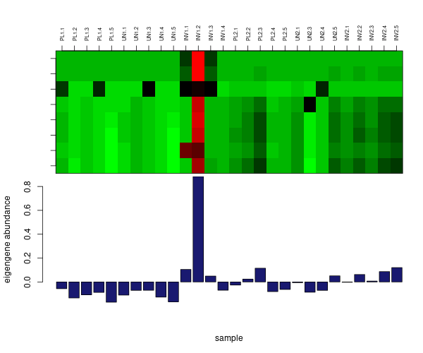

**Figure 14. Heatmap of genera abundances in each sample in the midnightblue module and eigengene abundance barplot.** Columns of the heatmap represent samples and rows represent each genus in the midnightblue module. Red indicates higher abundance of a genus and light green represents lower abundance. Higher bars in the barplot indicate higher abundances of genera in the midnightblue module in a given sample. PL samples are from pine plantations, UN samples are from uninvaded eucalypt forests adjacent to invaded forests, and INV are from pine-invaded eucalypt forests.

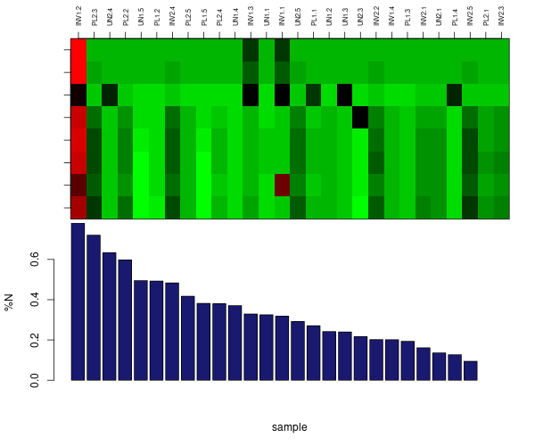

**Figure 15. Heatmap of genera abundances in each sample in the midnightblue module and barplot of soil %N.** Columns of the heatmap represent samples and rows represent each genus in the midnightblue module. Red indicates higher abundance of a genus and light green represents lower abundance. Increasing values on the y-axis of the barplot indicate more total N in a soil sample. PL samples are from pine plantations, UN samples are from uninvaded eucalypt forests adjacent to invaded forests, and INV are from pine-invaded eucalypt forests.

In these heatmaps, we can see that the abundance of midnightblue module genera in a sample does not correspond as well with high N as did the yellow module genera with low P, and is primarily driven by one sample. However, we still see some variation in the abundance of genera in the midnight blue module with forest type. The invaded forest at the second site has higher abundances of midnightblue module genera, indicating that the fungal communities change with pine invasion.

We additionally explored the midnight blue module that was significantly positively correlated with %C, but we discounted the correlation because it appears to be driven entirely by one outlier genus.

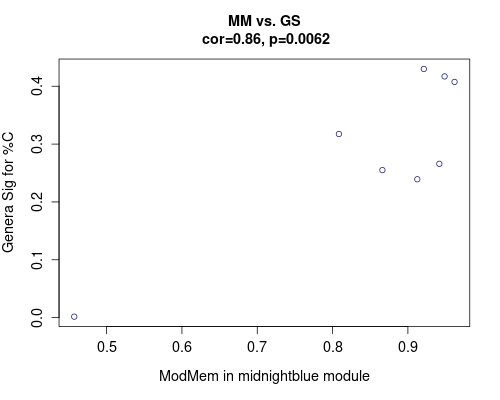

**Figure 16. Scatterplot of genera significance for %C vs. genera module membership in the midnightblue module.** Each point represents one genus in the module. Module membership in the midnightblue module for a given genus is a measure of the correlation of the module eigengene and the genus abundance profile. A tighter positive correlation between module membership and genera significance indicates higher significance of the module. cor is the correlation value, and p indicates the significance of the correlation.

# Conclusion

In conclusion, we found that total P was negatively correlated with one module of genera and total N was positively correlated with another module of genera, although the relationship with total N is primarily driven by 1 sample. With this analysis, we identified key fungal genera that are associated with low P and high N. Furthermore, abundance of the genera associated with low P varied with forest type, indicating that changes in fungal communities with pine invasion are related to changes in soil nutrients with pine invasion.

To hopefully draw more conclusive results, our next steps are to 1) increase sample size; and 2) use the original species-level OTU table as input for the WGCNA instead of collapsing to genera. We also hope to assign finer-level functions to taxa from existing functional databases for fungi to see if the taxa in modules associated with high or low soil nutrients have been previously associated with nutrient cycling functions.

#Citations

UNITE reference Database:

Abarenkov, Kessy; Zirk, Allan; Piirmann, Timo; Pöhönen, Raivo; Ivanov, Filipp; Nilsson, R. Henrik; Kõljalg, Urmas (2020): UNITE general FASTA release for Fungi. UNITE Community. 10.15156/BIO/786368

Funguild Database:

```r
bibentry(bibtype="article",
            title="FUNGuild: an open annotation tool for parsing fungal community datasets by ecological guild",
            author=c("Nhu H Nguyen", "Zewei Song", "Scott T Bates",
                     "Sara Branco", "Leho Tedersoo", "Jon Menke",
                     "Jonathan S Schilling", "Peter G Kennedy"),
            journal="Fungal Ecology",
            volume="20",
            pages="241--248",
            year="2016",
            publisher="Elsevier",
         textVersion = "Nguyen NH, Song Z, Bates ST, Branco S, Tedersoo L, Menke J, Schilling JS, Kennedy PG. 2016. FUNGuild: An open annotation tool for parsing fungal community datasets by ecological guild. Fungal Ecology 20:241–248."
         )
```

```
## Nguyen NH, Song Z, Bates ST, Branco S, Tedersoo L, Menke J, Schilling
## JS, Kennedy PG (2016). "FUNGuild: an open annotation tool for parsing
## fungal community datasets by ecological guild." _Fungal Ecology_, *20*,
## 241-248.
```